# Regression Models Course Project

Christian Ibanez

October 22, 2018

## Executive Summary

This report answers the following questions: “Is an automatic or manual transmission better for MPG?” “Quantify the MPG difference between automatic and manual transmissions”

The result of the analysis are the following: The difference of 7.24 between the Automatic and Manual in terms of mpg is statistically significant.

## Exploratory Data Analysis

Show the data structure of mtcars

```r
str(mtcars)
```

```
## 'data.frame':    32 obs. of  11 variables:
##  $ mpg : num  21 21 22.8 21.4 18.7 18.1 14.3 24.4 22.8 19.2 ...
##  $ cyl : num  6 6 4 6 8 6 8 4 4 6 ...
##  $ disp: num  160 160 108 258 360 ...
##  $ hp  : num  110 110 93 110 175 105 245 62 95 123 ...
##  $ drat: num  3.9 3.9 3.85 3.08 3.15 2.76 3.21 3.69 3.92 3.92 ...
##  $ wt  : num  2.62 2.88 2.32 3.21 3.44 ...
##  $ qsec: num  16.5 17 18.6 19.4 17 ...
##  $ vs  : num  0 0 1 1 0 1 0 1 1 1 ...
##  $ am  : num  1 1 1 0 0 0 0 0 0 0 ...
##  $ gear: num  4 4 4 3 3 3 3 4 4 4 ...
##  $ carb: num  4 4 1 1 2 1 4 2 2 4 ...
```

Convert to factors the “vs” and “am”

```r
mtcars$vs <- as.factor(mtcars$vs)
mtcars$am <- as.factor(mtcars$am)
num <- length(mtcars$am)
```

```r
levels(mtcars$am) <- c("Automatic", "Manual")
names(mtcars)[9]<-paste("Transmission")
```

The interquartile range of Manual Transmission is higher than Automatic Transmission when it comes to Miles per Gallon (As shown in the Appendix I). Let’s test this hypothesis.

## Inferential Data Analysis

Perform a t.test between the mean of Automatic and Manual for MPG (Assuming equal variance,Assuming unequal variance)

First we need to split the data

```r
Auto.Transmission <- subset(mtcars,select=mpg, Transmission == "Automatic")
Manual.Transmission <- subset(mtcars,select=mpg,Transmission == "Manual")
```

Assuming equal variance between the two groups

```r
t.test(Auto.Transmission,Manual.Transmission, var.equal = TRUE)
```

```
##
##  Two Sample t-test
##
## data:  Auto.Transmission and Manual.Transmission
## t = -4.1061, df = 30, p-value = 0.000285
## alternative hypothesis: true difference in means is not equal to 0
## 95 percent confidence interval:
##  -10.84837  -3.64151
## sample estimates:
## mean of x mean of y
##  17.14737  24.39231
```

Assuming unequal variance between the two groups

```r
t.test(Auto.Transmission,Manual.Transmission, var.equal = FALSE)
```

```
##
##  Welch Two Sample t-test
##
## data:  Auto.Transmission and Manual.Transmission
## t = -3.7671, df = 18.332, p-value = 0.001374
## alternative hypothesis: true difference in means is not equal to 0
## 95 percent confidence interval:
##  -11.280194  -3.209684
## sample estimates:
## mean of x mean of y
##  17.14737  24.39231
```

We showed that the difference between the mpg of Automatic and Manual is significant Calculate the significant diffenrence

```r
Signif.Diff <- mean(Manual.Transmission$mpg) - mean(Auto.Transmission$mpg)
Signif.Diff
```

```
## [1] 7.244939
```

## Regression Analysis

```r
LinReg <- lm(mpg ~ Transmission, data = mtcars)
```

Explore the data using the pairs plots. Based on the graph (Appendix II) we notice that disp, hp,wt are correlated to mpg. We will create a Multi Linear Regression for mpg that accounts the said 3 variable

```r
MultLinReg1 <- lm(mpg ~ disp + hp + wt, data = mtcars)
```

And another Multi Linear Regression that includes Transmission

```r
MultLinReg2 <- lm(mpg ~ Transmission + disp + hp + wt, data = mtcars)
```

Use ANOVA to compare the 3 regression models

```r
anova(LinReg, MultLinReg1, MultLinReg2)
```

```
## Analysis of Variance Table
##
## Model 1: mpg ~ Transmission
## Model 2: mpg ~ disp + hp + wt
## Model 3: mpg ~ Transmission + disp + hp + wt
##   Res.Df    RSS Df Sum of Sq       F   Pr(>F)
## 1     30 720.90
## 2     28 194.99  2    525.91 39.4632 9.68e-09 ***
## 3     27 179.91  1     15.08  2.2636   0.1441
## ---
## Signif. codes:  0 '***' 0.001 '**' 0.01 '*' 0.05 '.' 0.1 ' ' 1
```

Our Analysis of Variance shows that MultiLinReg1 is better than the other 2.

# I.

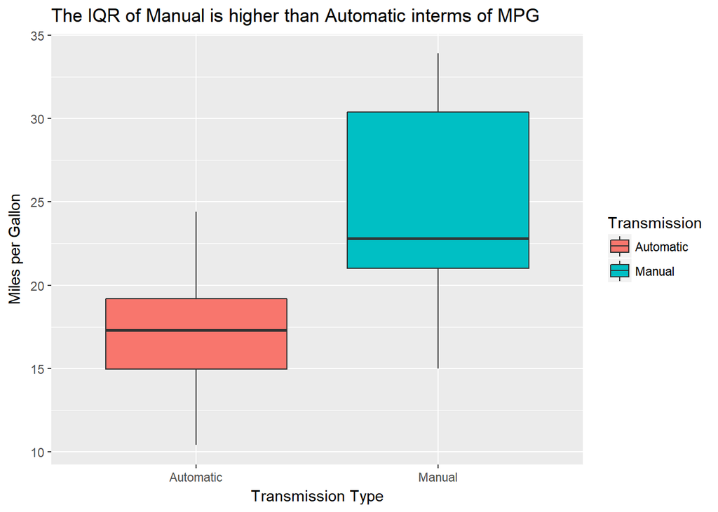

```r
library("ggplot2")
ggplot(aes(x = Transmission , y = mpg), data = mtcars) + geom_boxplot(aes(fill = Transmission)) + xlab("Transmission Type") + ylab("Miles per Gallon") + ggtitle("The IQR of Manual is higher than Automatic interms of MPG")
```

# II.

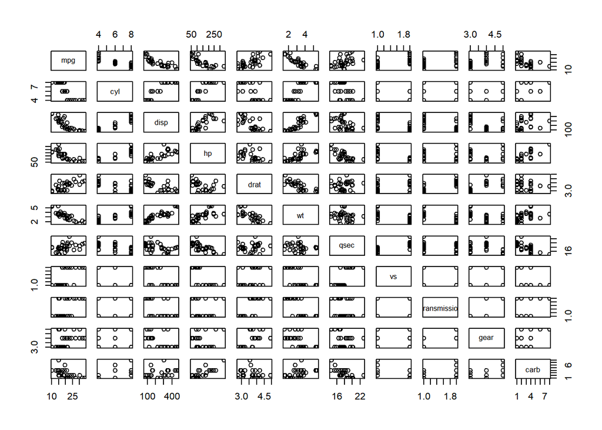

```r
pairs(mpg ~ ., data = mtcars)
```